# Laboratorio Manzanas

Daniel Sibaja Salazar

2024-04-02

# Preparación

```r
base=read.csv("manzanas.csv",sep= ";") # Se lee el archivo
base$trat=factor(base$trat) # Se pone el factor
levels(base$trat)= c("control","tapar","bolsa","limón")
#save(base,file="manzanas.Rdata") #Se guarda el archivo
```

# Análisis gráfico

```r
m=tapply(base$color,base$trat,mean);m #Media ppor trat
```

```
## control   tapar   bolsa   limón
##     5.4     3.2     2.8     1.8
```

```r
v=tapply(base$color,base$trat,var);v #Var por trat
```

```
##   control     tapar     bolsa     limón
## 0.4888889 1.7333333 1.0666667 0.6222222
```

```r
media=mean(base$color);media # Media general
```

```
## [1] 3.3
```

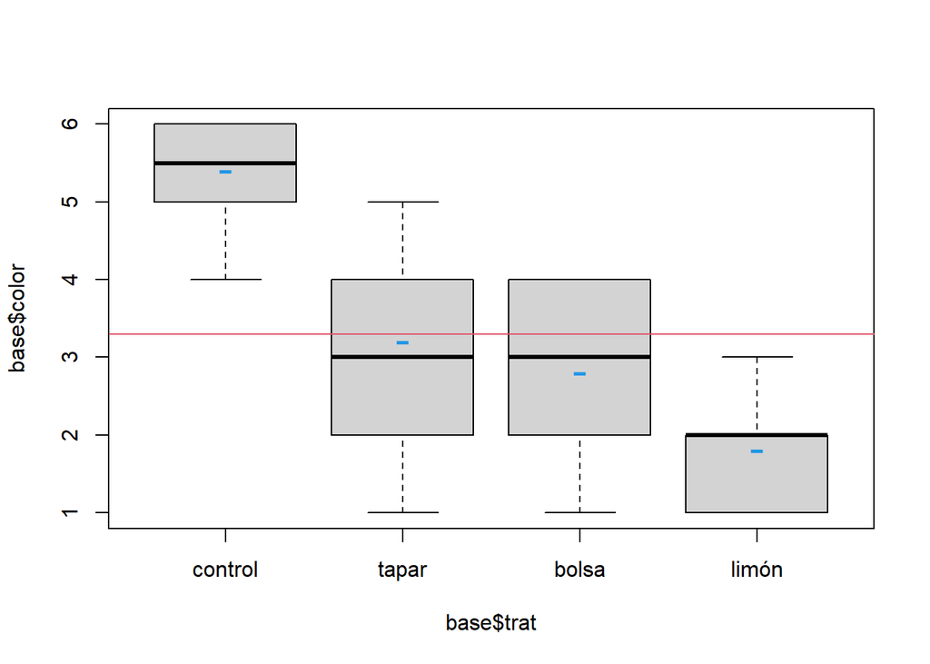

```r
boxplot(base$color~base$trat);abline(h=media,col=2);points(1:4,m,col=4,pch="-",cex=2) # Gráfico
```

```r
taus=m-media;taus# Efectos por tratamiento
```

```
## control   tapar   bolsa   limón
##     2.1    -0.1    -0.5    -1.5
```

```r
st=sum(taus);st # Suma de los efectos
```

```
## [1] 1.110223e-15
```

```r
ve=mean(v);ve # Varianza del error
```

```
## [1] 0.9777778
```

Los efectos significan que:

- El control aumenta el promedio general en 2.1
- Taparlos los disminuye en -0.1
- La bolsa lo disminuye en -0.5
- El limón lo disminuye en -1.5

# Análisis de varianza

```r
mod=lm(color~trat,data = base)
mod1=aov(color~trat,data = base)

mod;mod1;aov(mod) # Ajustar el modelo con diferentes fórmulas
```

```
##
## Call:
## lm(formula = color ~ trat, data = base)
##
## Coefficients:
## (Intercept)    trattapar    tratbolsa    tratlimón
##         5.4         -2.2         -2.6         -3.6
```

```
## Call:
##    aov(formula = color ~ trat, data = base)
##
## Terms:
##                 trat Residuals
## Sum of Squares  69.2      35.2
## Deg. of Freedom    3        36
##
## Residual standard error: 0.9888265
## Estimated effects may be unbalanced
```

```
## Call:
##    aov(formula = mod)
##
## Terms:
##                 trat Residuals
## Sum of Squares  69.2      35.2
## Deg. of Freedom    3        36
##
## Residual standard error: 0.9888265
## Estimated effects may be unbalanced
```

```r
anova(mod);anova(mod1) # Análisis de varianza
```

```
## Analysis of Variance Table
##
## Response: color
##           Df Sum Sq Mean Sq F value    Pr(>F)
## trat       3   69.2 23.0667  23.591 1.278e-08 ***
## Residuals 36   35.2  0.9778
## ---
## Signif. codes:  0 '***' 0.001 '**' 0.01 '*' 0.05 '.' 0.1 ' ' 1
```

```
## Analysis of Variance Table
##
## Response: color
##           Df Sum Sq Mean Sq F value    Pr(>F)
## trat       3   69.2 23.0667  23.591 1.278e-08 ***
## Residuals 36   35.2  0.9778
## ---
## Signif. codes:  0 '***' 0.001 '**' 0.01 '*' 0.05 '.' 0.1 ' ' 1
```

```r
cmres=anova(mod)[2,3] # Cuadrado medio residual
cmres;ve  # Son iguales
```

```
## [1] 0.9777778
```

```
## [1] 0.9777778
```

```r
df=anova(mod)[2,1];df
```

```
## [1] 36
```

Son 36 grados de libertad residuales porque se definen como n-k

```r
sctrat=anova(mod)[1,2];sctrat #Suma de cuadrados del tratamiento
```

```
## [1] 69.2
```

```r
10*sum(taus**2) # Es igual a la suma de cuadrados de tratamiento
```

```
## [1] 69.2
```

Se consideran solo 4 diferencias, no los 40 datos que hay, por esta razón hay que multiplicarlo por el número de réplicas que hay. Hay que darle un peso a esa diferencia.

```r
anova(mod)[1,3];anova(mod)[2,3]
```

```
## [1] 23.06667
```

```
## [1] 0.9777778
```

```r
(f=anova(mod)[1,3]/anova(mod)[2,3])
```

```
## [1] 23.59091
```

```r
(p=pf(f,3,36,lower.tail = F))
```

```
## [1] 1.278031e-08
```

Ya que el F está lejano al 1 esperable y la probabilidad asociada es prácticamente 0 hay sospechas de que si hay tratamientos que producen efectos diferentes de 0.

$$H0: \mu_1=\mu_2=\mu_3=\mu_4$$

H1: Al menos un par de promedios es distinto

Hay suficiente evidencia estadística para rechazar la hipótesis nula de que los promedios por tratamiento son todos iguales.

# Estimación de parámetros con el modelo de tratamiento de referencia.

```r
coef=mod$coefficients;coef
```

```
## (Intercept)   trattapar   tratbolsa   tratlimón
##         5.4        -2.2        -2.6        -3.6
```

2. El intercepto es la media del tratamiento que escogimos como referencia.
3. Los otros coeficientes representan la distancia que hay de la media de cada uno de los otros tratamientos con respecto a la media del control. **PREGUNTAR**

```r
model.matrix(mod)
```

```
##    (Intercept) trattapar tratbolsa tratlimón
## 1            1         1         0         0
## 2            1         1         0         0
## 3            1         1         0         0
## 4            1         1         0         0
## 5            1         1         0         0
## 6            1         1         0         0
## 7            1         1         0         0
## 8            1         1         0         0
## 9            1         1         0         0
## 10           1         1         0         0
## 11           1         0         1         0
## 12           1         0         1         0
## 13           1         0         1         0
## 14           1         0         1         0
```

[output cut: 31 more lines]

## Efectos muestrales

```r
coef
```

```
## (Intercept)   trattapar   tratbolsa   tratlimón
##         5.4        -2.2        -2.6        -3.6
```

```r
t1=c(1,0,0,0)
t2=c(1,1,0,0)
t3=c(1,0,1,0)
t4=c(1,0,0,1)

mc=c(coef%*%t1,coef%*%t2,coef%*%t3,coef%*%t4);mc
```

```
## [1] 5.4 3.2 2.8 1.8
```

```r
mc-media;taus
```

```
## [1]  2.1 -0.1 -0.5 -1.5
```

```
## control   tapar   bolsa   limón
##     2.1    -0.1    -0.5    -1.5
```

## Efectos automáticamente

```r
model.tables(mod1)
```

```
## Tables of effects
##
##  trat
## trat
## control   tapar   bolsa   limón
##     2.1    -0.1    -0.5    -1.5
```

# Modelo de suma Nula

```r
options(contrasts=c("contr.sum","contr.poly"))# Cambiar a suma nula

# options(contrasts=c("contr.treatment","contr.poly")) # Cambiar a referencia


contrasts(base$trat)
```

```
##         [,1] [,2] [,3]
## control    1    0    0
## tapar      0    1    0
## bolsa      0    0    1
## limón     -1   -1   -1
```

## Repetir el punto 4.

```r
mod2=lm(color~trat,data = base)
mod2aov=aov(color~trat,data = base)

coef2=mod2$coefficients;coef2
```

```
## (Intercept)       trat1       trat2       trat3
##         3.3         2.1        -0.1        -0.5
```

En este caso el intercepto es la general y los demás coeficientes son los efectos por tratamiento sin tomar en cuenta el último

```r
model.matrix(mod2)
```

```
##    (Intercept) trat1 trat2 trat3
## 1            1     0     1     0
## 2            1     0     1     0
## 3            1     0     1     0
## 4            1     0     1     0
## 5            1     0     1     0
## 6            1     0     1     0
## 7            1     0     1     0
## 8            1     0     1     0
## 9            1     0     1     0
## 10           1     0     1     0
## 11           1     0     0     1
## 12           1     0     0     1
## 13           1     0     0     1
## 14           1     0     0     1
```

[output cut: 31 more lines]

```r
coef2
```

```
## (Intercept)       trat1       trat2       trat3
##         3.3         2.1        -0.1        -0.5
```

```r
v1=c(1,1,0,0)
v2=c(1,0,1,0)
v3=c(1,0,0,1)
v4=c(1,-1,-1,-1)

mc2=c(coef2%*%v1,coef2%*%v2,coef2%*%v3,coef2%*%v4)

mc2-media
```

```
## [1]  2.1 -0.1 -0.5 -1.5
```

```r
model.tables(mod2aov)
```

```
## Tables of effects
##
##  trat
## trat
## control   tapar   bolsa   limón
##     2.1    -0.1    -0.5    -1.5
```

# Factor con dos niveles

```r
base1=rbind(base[base$trat=="control",],base[base$trat=="tapar",])

base1$trat=factor(as.numeric(base1$trat))

mod3=lm(color~trat,data = base1)

anova(mod3) # Se rechaza la hipótesis nula de igualdad de medias
```

```
## Analysis of Variance Table
##
## Response: color
##           Df Sum Sq Mean Sq F value    Pr(>F)
## trat       1   24.2 24.2000   21.78 0.0001919 ***
## Residuals 18   20.0  1.1111
## ---
## Signif. codes:  0 '***' 0.001 '**' 0.01 '*' 0.05 '.' 0.1 ' ' 1
```

```r
summary(mod3) # Se rechaza la hipótesis nula t de igualdad de medias
```

```
##
## Call:
## lm(formula = color ~ trat, data = base1)
##
## Residuals:
##    Min     1Q Median     3Q    Max
##   -2.2   -0.4   -0.2    0.6    1.8
##
## Coefficients:
##             Estimate Std. Error t value Pr(>|t|)
## (Intercept)   4.3000     0.2357  18.243 4.68e-13 ***
## trat1         1.1000     0.2357   4.667 0.000192 ***
## ---
## Signif. codes:  0 '***' 0.001 '**' 0.01 '*' 0.05 '.' 0.1 ' ' 1
##
## Residual standard error: 1.054 on 18 degrees of freedom
## Multiple R-squared:  0.5475, Adjusted R-squared:  0.5224
## F-statistic: 21.78 on 1 and 18 DF,  p-value: 0.0001919
```

Ambos resultados son iguales, en ambos casos se rechaza la hipótesis nula

## Hecho a mano.

```r
t1t=1.1
eet=0.2357

t=t1t/eet;t
```

```
## [1] 4.66695
```

```r
gl=20-2

(1-pt(t,gl))*2 # Se multiplica por dos porque es de dos colas
```

```
## [1] 0.0001918602
```

```r
pt(t,gl,lower.tail = F)*2 ## Otra forma de hacerlo
```

```
## [1] 0.0001918602
```